# 3.5 Computational Technique

As a setting to illustrate computer techniques for describing variability, take the data that Galton collected on the heights of adult children and their parents. The file `galton.csv` stores these data in a modern, case/variable format.

```r
require(mosaic)
Galton = read.csv("http://tiny.cc/mosaic/galton.csv")
# As it happens, Galton is already loaded by mosaic from the mosaicData package.
# So you don't need the read.csv(); we use it here for the sake of generality.
```

## Simple Statistical Calculations

```r
# [Always a space on both sides of an operator]
mean( ~ height, data = Galton)
```

```
## [1] 66.76069
```

```r
median( ~ height, data = Galton)
```

```
## [1] 66.5
```

```r
sd( ~ height, data = Galton)
```

```
## [1] 3.582918
```

```r
var( ~ height, data = Galton)
```

```
## [1] 12.8373
```

Notice that the variance function `var()` [avoid the nesting that you get with the parenthetical form (`var()`)] returns the square of the standard deviation `sd()`. Having both is merely a convenience.

Why the tilde? In all these commands the first argument (`~ height`) is recognized by the interpreter as a `model formula`. Model language involves the tilde, and the tilde must be followed by a variable. These commands (in their default non-mosaic form) can also take numeric vectors (columns of numbers) as arguments, but then the convenience of the `data =` designation is not available:

```r
mean(Galton$height)
```

```
## [1] 66.76069
```

```r
median(Galton$height)
```

```
## [1] 66.5
```

As we have seen before, R’s model language also allows more sophisticated model arguments, as in

```r
median(height ~ sex, data = Galton)
```

```
##    F    M
## 64.0 69.2
```

A percentile tells where a given value falls in a distribution. For example, a height of 63 inches is on the short side in Galton’s data:

```r
pdata( ~ height, 63, data = Galton)
```

```
## [1] 0.1915367
```

Only about 19 % of the cases have a height less than or equal to 63 inches. The `pdata` operator takes one or more values as a second argument (here, 63) and finds where they fall in the distribution of values in the first argument (`height`).

A quantile refers to the same sort of calculation, but inverted. Instead of giving a value in the same units as the distribution, you give a probability: a number between 0 and 1. The `qdata` operator then calculates the value whose percentile would be that value. What’s the 20th percentile of Galton’s heights?

```r
qdata( ~ height, 0.2, data = Galton)
```

```
##        p quantile
##      0.2     63.5
```

Remember that the probability is given as a number between 0 and 1, so use 0.50 to indicate that you want the value which falls at the 50th percentile.

```r
qdata( ~ height, 0.5, data = Galton)
```

```
##        p quantile
##      0.5     66.5
```

```r
median( ~ height, data = Galton)
```

```
## [1] 66.5
```

```r
# [Note: formula should be first argument.]
qdata( ~ height, c(0.25, 0.75), data = Galton)
```

```
##     quantile    p
## 25%     64.0 0.25
## 75%     69.7 0.75
```

1. The 2.5th and 97.5th percentile — in other words, the 95 percent coverage interval:

```r
qdata( ~ height, c(0.025, 0.975), data = Galton)
```

```
##       quantile     p
## 2.5%        60 0.025
## 97.5%       73 0.975
```

The interquartile range is the width of the 50 percent coverage interval:

```r
IQR( ~ height, data = Galton)
```

```
## [1] 5.7
```

## Simple Statistical Graphics

### Histograms and Distributions

Constructing a histogram involves dividing the range of a variable up into bins and counting how many cases fall into each bin. This is done in an almost entirely automatic way:

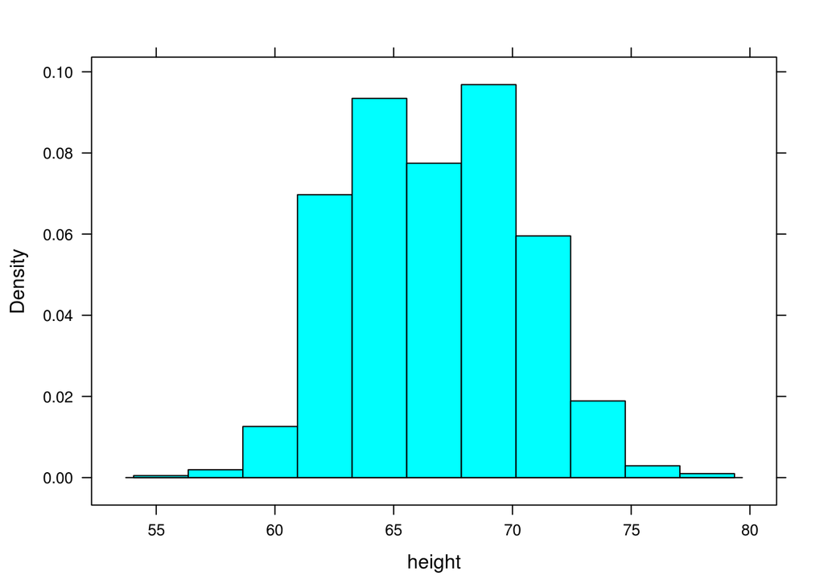

```r
histogram( ~ height, data = Galton)
```

When constructing a histogram, R makes an automatic but sensible choice of the number of bins. If you like, you can control this yourself. For instance:

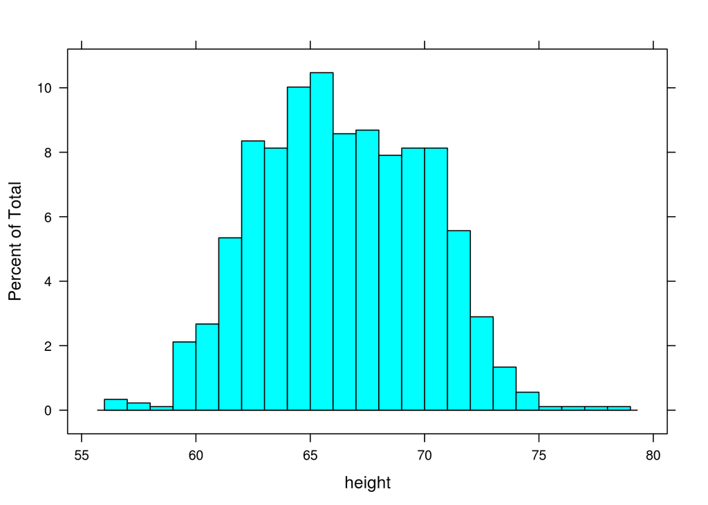

```r
histogram( ~ height, data = Galton, breaks = 25 )
```

The horizontal axis of the histogram is always in the units of the variable. For the histograms above, the horizontal axis is in “inches” because that is the unit of the `height` variable.

The vertical axis is conventionally drawn in one of three ways: controlled by an optional argument named `type`.

1. **Absolute Frequency or Counts**

A simple count of the number of cases that falls into each bin. This mode is set with `type="count"` as in

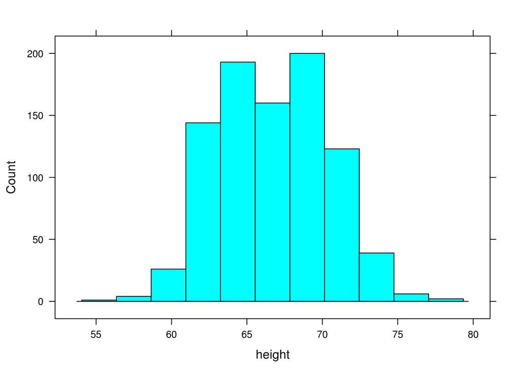

```r
histogram( ~ height, data = Galton, type = "count")
```

1. **Relative Frequency**

1. **Density**

The vertical axis *area* of the bar gives the relative proportion of cases that fall into the bin. Set `type = "density"`. In a density plot, areas can be interpreted as probabilities and the area under the entire histogram is equal to 1.

Other useful optional arguments set the labels for the axes and the graph as a whole and color the bars. For example,

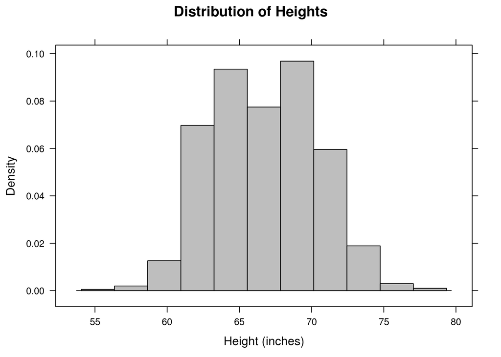

```r
histogram( ~ height, data = Galton, type = "density",
     xlab="Height (inches)",
     main="Distribution of Heights",
     col="gray")
```

### Density Plots

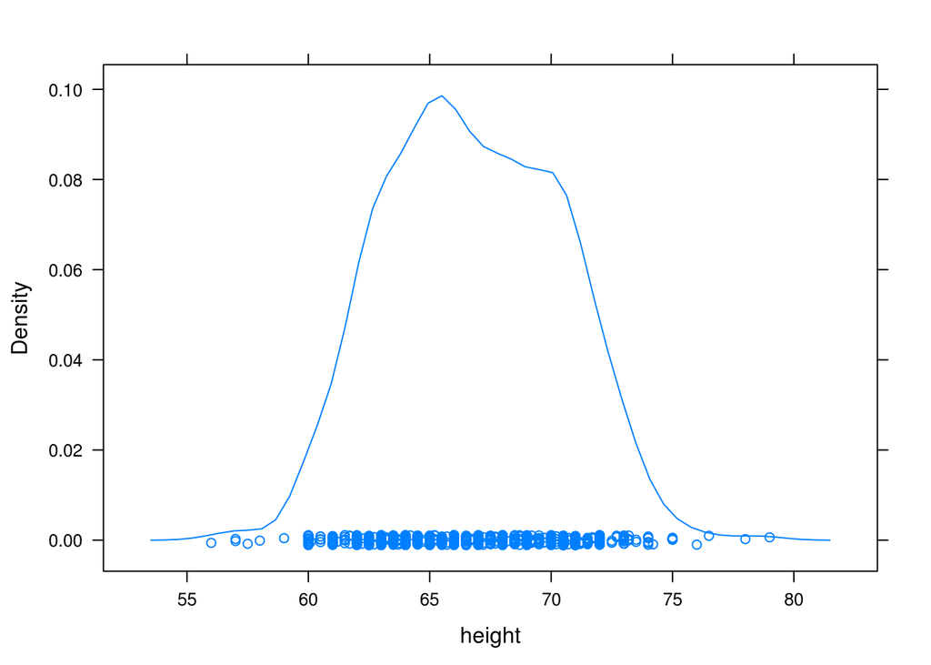

```r
densityplot( ~ height, data = Galton)
```

If you want to suppress the rug-like plotting of points at the bottom of the graph, use `densityplot( ~ height, data = Galton, plot.points = FALSE)`.

### Box-and-Whisker Plots

Box-and-whisker plots are made with the `bwplot` command:

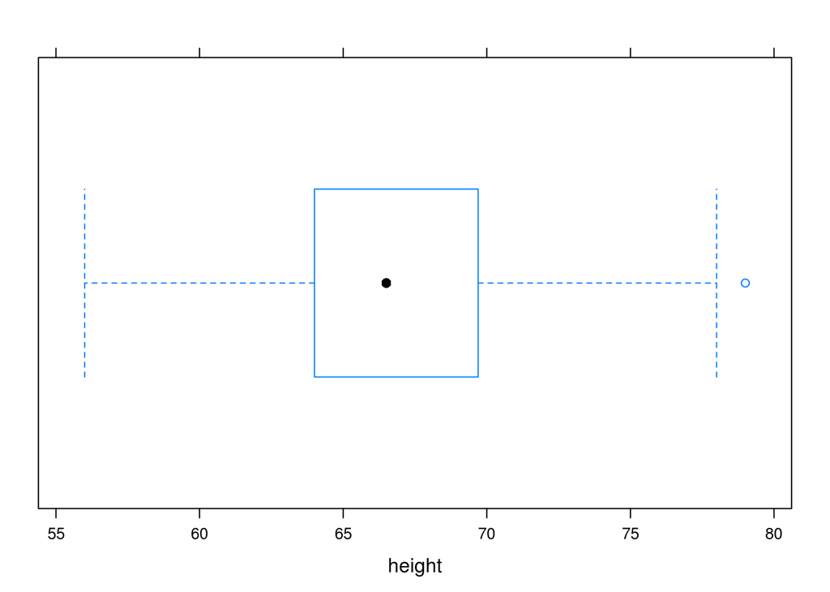

```r
bwplot( ~ height, data = Galton)
```

The median is represented by the heavy dot in the middle. Outliers, if any, are marked by dots outside the whiskers.

The real power of the box-and-whisker plot is for comparing distributions. This will be raised again more systematically in later chapters, but just to illustrate, here is how to compare the heights of males and females:

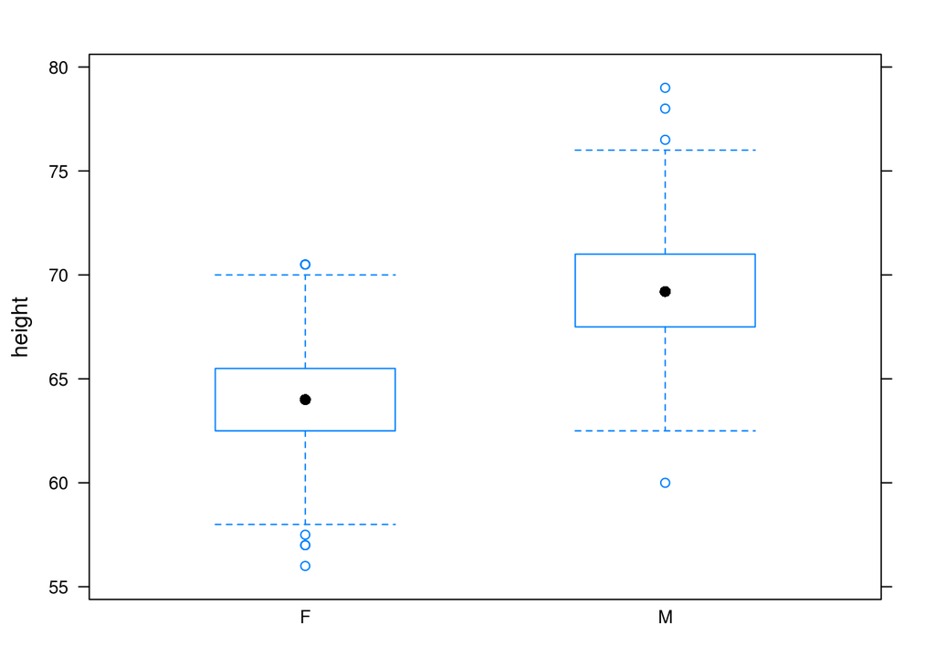

```r
bwplot(height ~ sex, data = Galton)
```

## Displays of Categorical Variables

For categorical variables, it makes no sense to compute descriptive statistics such as the mean, standard deviation, or variance. Instead, look at the number of cases at each level of the variable.

```r
tally( ~ sex, data = Galton)
```

```
##
##   F   M
## 433 465
```

Proportions can be found by dividing the tallies by the total:

```r
tally( ~ sex, data = Galton)/nrow(Galton)
```

```
##
##         F         M
## 0.4821826 0.5178174
```